# Lab 5: Apache Spark Structured Streaming

```python
Name: Monier Ashraf Monier Lawande
ID: 221002188
```

# Introduction:

### Batch vs Stream data processing:

Batch data processing is the processing of data as a collection of points that have been stored or grouped within a specific time interval. While in stream data processing, the data is fed into the analytics system as soon as the data arrive.

### Apache Spark Structured Streaming:

Spark Structured Streaming is an open source scalable and fault-tolerant stream processing engine built on the top of Spark SQL engine. Using Spark Structured Streaming, you can express streaming data processing as batch.

In this lab, we are going to practice SQL-like operations (e.g. Select, Where, GroupBy)

### Programming Model:

Structured Streaming treats a data stream as a table that is being continuously appended. This is what makes stream processing in Structured Streaming similar to batch processing.

[figure not shown]

A query on the input data generates the “Results Table”.

#### Output Modes:

By output, we mean that the data written to the sink and there are three modes for output:  
**1. Complete Mode** - The whole updated “Results Table” will be written to the sink.  
**2. Append Mode** - Only the appended part in the “Results Table”, since the last write operation, will be written to the sink. Obviously, it is applicable when the rows in the “Results Table” are not expected to change.  
**3. Update Mode** - Only the rows that were updated in the “Results Table”, since the last write operation, will be written to the sink.

Please refer to [this link](https://spark.apache.org/docs/latest/structured-streaming-programming-guide.html) for more information about Spark Structured Streaming

# 1. Stream Data from a Socket

### Task 1.1: Structured Streaming Word Count:

Let us practice the word count example that we have practiced in the last session but using Spark Structured Streaming this time. We will be reading the stream from a socket. To simulate a socket, we will use Netcat to serve as the data source that generates data on a specific port.

- To open port for streaming: `nc -l 5555`
- To List jobs on the port: `lsof -i:5555`
- To Kill jobs: `kill -9 id`

```python
from pyspark import SparkContext
from pyspark.sql import SparkSession
from pyspark.sql.functions import explode
from pyspark.sql.functions import split
```

- Create a local SparkSession and set the name of the application

```python
sc = SparkContext()
```

```python
spark = SparkSession(sc).builder.appName("StructuredNetworkWordCount").getOrCreate()
```

- To reduce the amount of information (logs) that are printed to the terminal we will restrict the logs to be only for errors.

```python
spark.sparkContext.setLogLevel("ERROR")
```

- Create a streaming DataFrame (*lines*) that receives input data from a socket source.

```python
hello
world
big
```

```python
lines = spark.readStream.format("socket").option("host", "localhost").option("port", 4444).load()
```

- The lines of the dataFrame will be in an unbounded table. This table contains one column with a default name "value".
- In the following part, we will use "split" built-in function to split each line into multiple rows with a word in each row. Moreover, we will use the "alias" function to give a new column name "word" to the resulting DataFrame.

```python
words = lines.select(explode(split(lines.value, " ")).alias("word"))
```

- Write a query that will count the word occurrences

```python
wordCounts = words.groupBy("word").count()
```

- To start receiving data and computing, we set it up to print the complete set of counts to the console every time they are updated. Then, we are going to start the streaming computation.

```python
query = wordCounts \
    .writeStream \
    .outputMode("complete") \
    .format("console") \
    .start()
```

The streaming computation should have started then. We should wait for the termination of the query to prevent the process from exiting while the query is active.

```python
query.awaitTermination()
```

```python
from IPython.display import Image
```

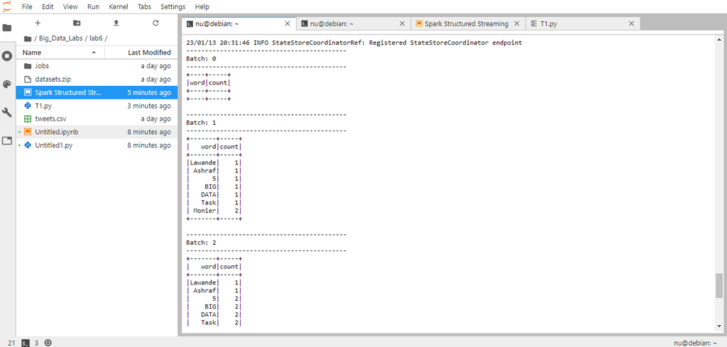

```python
Image(filename="/home/bitnami/Big_Data_Labs/lab6/Images/1.png")
```

You will notice that the output is printed out to the terminal as soon as you write in the Netcat terminal.

```python
from pyspark.sql import SparkSession
from pyspark.sql.functions import explode
from pyspark.sql.functions import split


# build spark session
sc = SparkContext()
spark = SparkSession(sc) \
    .builder \
    .appName("Spark Structured Streaming Lab") \
    .getOrCreate()

# Set the log level to error
spark.sparkContext.setLogLevel("ERROR")

#start reading from the socket on port 5555
lines = spark.readStream.format("socket").option("host","localhost").option("port",5555).load()

# Split lines
words = lines.select(explode(split(lines.value," ")).alias("word"))

# count words
wordCounts = words.groupBy("word").count()

# write the stream
query = wordCounts.writeStream.outputMode("complete").format("console").start()
query.awaitTermination()
```

To practice Submitting the job to the spark:

- Assemble the codes you created in `.py file` with name wordcount.py
- Open a terminal and open the port you specified in the Spark application using netcat.
- Open another terminal and run the following command: `spark-submit <path to the file>/wordcount.py`

Now, you need to write on the NetCat terminal (and press enter) and you will see the results of the number of words printed out in the Structured Streaming console.

### Task 1.2: Word count over time windows:

- In this task, we need to aggregate (word count) per time window and word. For this purpose, we need a time-progress (timestamp) column in our data. Looking at the current input we just have a dataframe that holds the words. What we need to do is to assign a processing time stamp by adding a new column to the dataframe and assign the current system time to each record.
- We need to modify the code above to add this column so that. We have the `lines` dataframe to look like `(value, timestamp)`.

```python
from pyspark.sql import SparkSession
from pyspark.sql.functions import explode
from pyspark.sql.functions import split
from pyspark.sql.functions import *


spark = SparkSession.builder.appName("Spark Structured Streaming Lab").getOrCreate()
spark.sparkContext.setLogLevel("ERROR")

# Added includeTimestamp option
lines = spark.readStream.format("socket").option("host","localhost").\
option("port",5553).option("includeTimestamp", "true").load()

# Split line into => word, Time
words = lines.select(explode(split(lines.value, ' ')).alias('word'),lines.timestamp)

# Group by Timestamp, word
The_window_count = words.groupBy(window(words.timestamp, '10 seconds', '5 seconds'),words.word).count()

# Stream the output
query = The_window_count.writeStream.outputMode("complete").format("console").start()
query.awaitTermination()
```

### Try the code in the terminal and put a screenshot of the output here

```python
## Screenshot Here
```

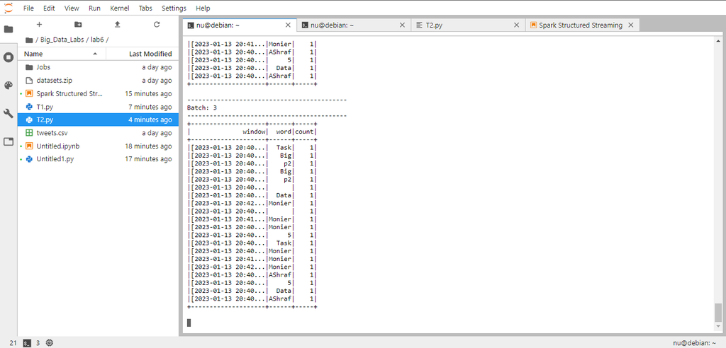

```python
Image(filename="/home/bitnami/Big_Data_Labs/lab6/Images/2.png")
```

# 2. Stream data from directory of files

### Task 2: Processing stream from files:

- In this task we will be using data from [London crime dataset](https://data.police.uk/data/) . Attached with this lab, datasets.zip, is a list of csv files that we will be using in this task.
- Create a folder for this lab practice called "subdata" to which we will be dropping files while the job is running to observe the behavior of structured streaming.

```python
!unzip datasets.zip -d Data/
```

```
Archive:  datasets.zip
   creating: Data/datasets/
  inflating: Data/datasets/xaa.csv
  inflating: Data/datasets/xal.csv
  inflating: Data/datasets/xam.csv
  inflating: Data/datasets/xan.csv
  inflating: Data/datasets/xao.csv
  inflating: Data/datasets/xap.csv
  inflating: Data/datasets/xaq.csv
  inflating: Data/datasets/xar.csv
```

```python
from pyspark.sql.types import *
from pyspark.sql import SparkSession
from pyspark.sql.functions import  col


sparkSession = SparkSession.builder.master("local")\
.appName("ProcessingStreamFromFiles").getOrCreate()


sparkSession.sparkContext.setLogLevel("ERROR")

schema = StructType([StructField("lsoa_code", StringType(), True),\
                     StructField("borough", StringType(), True),\
                     StructField("major_category", StringType(), True),\
                     StructField("minor_category", StringType(), True),\
                     StructField("value", StringType(), True),\
                     StructField("year", StringType(), True),\
                     StructField("month", StringType(), True)])


fileStreamDF = sparkSession.readStream\
               .option("header", "true")\
               .option("maxFilesPerTrigger", 1)\
               .schema(schema)\
               .csv("Big-Data-Labs/Lab6/subdata")


recordsPerBorough = fileStreamDF.groupBy("borough")\
                    .count()\
                    .orderBy("count", ascending=False)



query = recordsPerBorough.writeStream\
        .outputMode("complete")\
        .format("console")\
        .option("truncate", "false")\
         .option("numRows", 20)\
         .start()\
         .awaitTermination()
```

### Screenshot of the output

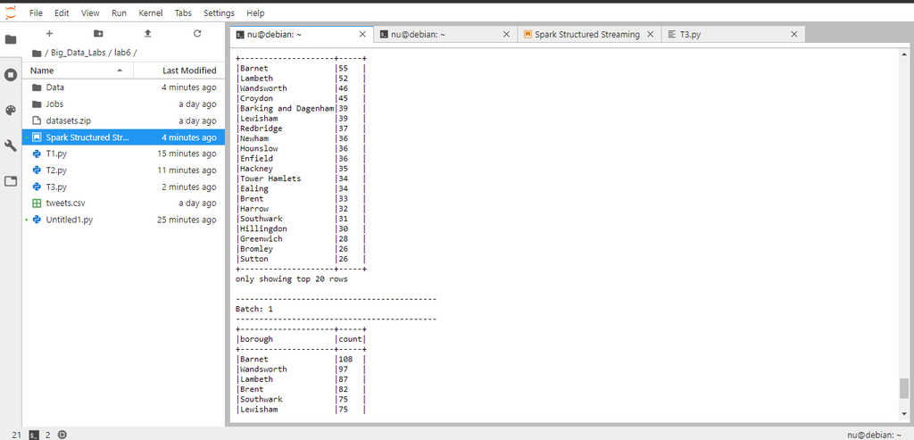

```python
Image(filename="/home/bitnami/Big_Data_Labs/lab6/Images/3.png")
```

## Task 3: Twitter Stream:

### Task 3.1:

We are going to use [Tweepy](https://tweepy.readthedocs.io/en/v3.5.0/) . Tweepy is an open source Python library which helps in communicating with Twitter API.

We will start by getting the required credentials that will help us to access Twitter.

- From this [website,](https://developer.twitter.com/en/apps) create your app in twitter. If you did not yet have a twitter account, please create one.
- After creating your own app, please get the following four keys:
  1. API key
  2. API secret key
  3. Access token
  4. Access token secret
- Please refer to this [video](https://www.youtube.com/watch?v=M_gGUqhCJoU) for more information.
- Attached with this lab the files `CleanedTweets.py` and `twitterStreaming.py`.
- Open `twitterStreaming.py` and add your own keys that you got in the previous step. In this file, we are connecting to the Twitter, receiving the stream of tweets and streaming them into localhost.

To run the files:

- First open a terminal and write the following command:  
  `python Big-Data-Labs/Lab6/twitterStreaming.py world cup`
- Open another terminal and wrtie the following command:  
  `Big-Data-Labs/Lab6/CleanedTweets.py`

### Put a screenshot of the task

```python
t = "Ahmed went to the movies yesterday"
```

```python
pip install gensim
```

[output not shown]

```python
from gensim.parsing.preprocessing import remove_stopwords
```

```python
text = "Nick likes to play football, however he is not too fond of tennis."
filtered_sentence = remove_stopwords(text)

print(filtered_sentence)
```

```
Nick likes play football, fond tennis.
```

```python
pattern = re.compile(r'\b(' + r'|'.join(stopwords.words('english')) + r')\b\s*')
```

```python
text = pattern.sub('', t)
```

```python
text
```

```
'Ahmed went movies yesterday'
```

```python
text = ' '.join([word for word in t.split() if word not in (stopwords.words('english'))])
```

```python
# screenshot of the ouput
```

[figure not shown]

```python
Image(filename="/home/bitnami/Big_Data_Labs/lab6/Images/4.png")
```

### Task 3.2 Modify the CleanedTweets.py file to remove the stopwords from the tweets

```python
# screenshot of the output
```

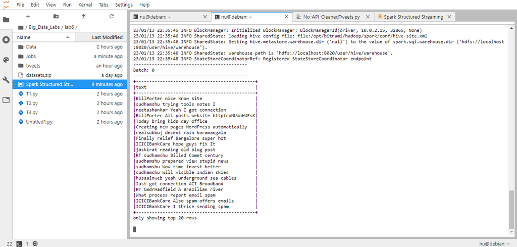

```python
Image(filename="/home/bitnami/Big_Data_Labs/lab6/Images/5.png")
```

```python
from gensim.parsing.preprocessing import remove_stopwords

def CleanTweet(tweet):
    cleaned = re.sub("[^A-Za-z\s]", "", str(tweet))
    cleaned1=remove_stopwords(cleaned)
    truncated = " ".join(cleaned1.split()[:5])




    return truncated
```